# PML

Christopher Mooney

06/18/2015

## Summary

This analysis was created from measuring invidivuals performing weight lifting excercises. They performed these correctly and incorrecltly. This has become possible from such devices as Jawbone, Nike Fuel Band and Fitbit. One could classify these as the internet of things. It is a very exciting analysis because we now have more data than ever before and this is a perfect example how data can help improve peoples lifes from predictive modeling.

## Load packages

```r
suppressMessages(library(caret))
suppressMessages(library(randomForest))
suppressMessages(library(rpart))
suppressMessages(library(sqldf))
suppressMessages(library(ggplot2))
```

## Load Data

```r
FilePath = '/home/christopher/Downloads/'
TrainingFile= 'pml-training.csv'
TrainingFile = paste(FilePath,TrainingFile,sep='')

TestingFile = 'pml-testing.csv'
TestingFile = paste(FilePath,TestingFile,sep='')

PML = read.csv(TrainingFile,header=T)
PMLPostTest = read.csv(TestingFile,header=T)
#DropID
PML$X = NULL
```

## Data Cleaning

There are many columns that are sparse so we will remove this values. Primarily this stage is done solely on train then applied to test. However, we are not performing any variable transformation so we do not need to do this seperately on test and train.

```r
list = c()
for(i in 1:length(colnames(PML))){

  # Agg data
  Cases = table(PML[colnames(PML)[i]])
  Cases = sort(Cases,decreasing=T)

  # Drop Variables that are > 95% missing
  if(sum(is.na(PML[colnames(PML)[i]]))/nrow(PML) >.95)
  {
    list = c(list , c=colnames(PML)[i])
  }
  # Drop variables that are close to static (Warning becareful sometimes that minroity help explain variance)
  else if(Cases[1]/nrow(PML)>.95)
  {
    list = c(list , c=colnames(PML)[i])
  }
}
```

## Drop variables that are missing more than 95% or static columns

```r
print('The following variables will be dropped')
```

```
## [1] "The following variables will be dropped"
```

```r
print(as.data.frame(list))
```

```
##                         list
## 1                 new_window
## 2         kurtosis_roll_belt
## 3        kurtosis_picth_belt
## 4          kurtosis_yaw_belt
## 5         skewness_roll_belt
## 6       skewness_roll_belt.1
## 7          skewness_yaw_belt
## 8              max_roll_belt
## 9             max_picth_belt
## 10              max_yaw_belt
## 11             min_roll_belt
## 12            min_pitch_belt
## 13              min_yaw_belt
## 14       amplitude_roll_belt
```

[output cut: 87 more lines]

```r
PML = PML[, !(colnames(PML) %in% c((list)))]
```

## Data Partitioning

```r
trainIndex <- createDataPartition(PML$classe, p = .6,
                                  list = FALSE,
                                  times = 1)

PMLTrain <- PML[ trainIndex,]
PMLTest  <- PML[-trainIndex,]
```

## Modeling

```r
myControl <- trainControl(method='repeatedcv', number=5, returnResamp='none')
gbmGrid <-  expand.grid(interaction.depth = c(1, 5, 9),
                        n.trees = (1:30)*50,
                        shrinkage = 0.1)

# The models we try are: RandomForest, GBM, NN, LogitBoost
predictors <- names(PMLTrain)[names(PMLTrain) != 'classe']
PMLTrain <- PMLTrain[,colSums(is.na(PMLTrain))<nrow(PMLTrain)]

system.time(model_rpart <- train(PMLTrain[,predictors], PMLTrain[,'classe'], method='rpart', trControl=myControl))
```

```
##    user  system elapsed
##  11.124   0.071  11.394
```

```r
system.time(model_rf <- train(PMLTrain[,predictors], PMLTrain[,'classe'], method='rf', trControl=myControl))
```

```
##    user  system elapsed
## 851.500  11.269 922.292
```

```r
system.time(model_nb <- train(PMLTrain[,predictors], PMLTrain[,'classe'], method='nb', trControl=myControl))
```

```
##    user  system elapsed
## 189.326   8.740 199.958
```

```r
# Model Results
pred_rpart = predict(model_rpart, PMLTest[,predictors])
pred_rf = predict(model_rf, PMLTest[,predictors])
pred_NB = predict(model_nb, PMLTest[,predictors])
```

## Model Results

```r
print('Tree Model')
```

```
## [1] "Tree Model"
```

```r
xtab <- table(pred_rpart, PMLTest$classe)
confusionMatrix(xtab)
```

```
## Confusion Matrix and Statistics
##
##
## pred_rpart    A    B    C    D    E
##          A 1436  123    0    0    0
##          B  796 1380 1008  241    0
##          C    0    0    0    0    0
##          D    0    0    0    0    0
##          E    0   15  360 1045 1442
##
## Overall Statistics
##
##                Accuracy : 0.5427
##                  95% CI : (0.5316, 0.5538)
##     No Information Rate : 0.2845
##     P-Value [Acc > NIR] : < 2.2e-16
##
##                   Kappa : 0.4226
##  Mcnemar's Test P-Value : NA
##
## Statistics by Class:
##
##                      Class: A Class: B Class: C Class: D Class: E
## Sensitivity            0.6434   0.9091   0.0000   0.0000   1.0000
## Specificity            0.9781   0.6768   1.0000   1.0000   0.7783
## Pos Pred Value         0.9211   0.4029      NaN      NaN   0.5038
## Neg Pred Value         0.8734   0.9688   0.8256   0.8361   1.0000
## Prevalence             0.2845   0.1935   0.1744   0.1639   0.1838
## Detection Rate         0.1830   0.1759   0.0000   0.0000   0.1838
## Detection Prevalence   0.1987   0.4365   0.0000   0.0000   0.3648
## Balanced Accuracy      0.8107   0.7930   0.5000   0.5000   0.8891
```

```r
print('RF Model')
```

```
## [1] "RF Model"
```

```r
xtab <- table(pred_rf, PMLTest$classe)
confusionMatrix(xtab)
```

```
## Confusion Matrix and Statistics
##
##
## pred_rf    A    B    C    D    E
##       A 2232    1    0    0    0
##       B    0 1517    1    0    0
##       C    0    0 1366    1    0
##       D    0    0    1 1285    2
##       E    0    0    0    0 1440
##
## Overall Statistics
##
##                Accuracy : 0.9992
##                  95% CI : (0.9983, 0.9997)
##     No Information Rate : 0.2845
##     P-Value [Acc > NIR] : < 2.2e-16
##
##                   Kappa : 0.999
##  Mcnemar's Test P-Value : NA
##
## Statistics by Class:
##
##                      Class: A Class: B Class: C Class: D Class: E
## Sensitivity            1.0000   0.9993   0.9985   0.9992   0.9986
## Specificity            0.9998   0.9998   0.9998   0.9995   1.0000
## Pos Pred Value         0.9996   0.9993   0.9993   0.9977   1.0000
## Neg Pred Value         1.0000   0.9998   0.9997   0.9998   0.9997
## Prevalence             0.2845   0.1935   0.1744   0.1639   0.1838
## Detection Rate         0.2845   0.1933   0.1741   0.1638   0.1835
## Detection Prevalence   0.2846   0.1935   0.1742   0.1642   0.1835
## Balanced Accuracy      0.9999   0.9996   0.9992   0.9994   0.9993
```

```r
print('NB Model')
```

```
## [1] "NB Model"
```

```r
xtab <- table(pred_NB, PMLTest$classe)
confusionMatrix(xtab)
```

```
## Confusion Matrix and Statistics
##
##
## pred_NB    A    B    C    D    E
##       A 2156  272  224   55   47
##       B   35 1094   85    0   14
##       C   21  146 1043  163   60
##       D   19    6   16 1013   63
##       E    1    0    0   55 1258
##
## Overall Statistics
##
##                Accuracy : 0.8366
##                  95% CI : (0.8282, 0.8447)
##     No Information Rate : 0.2845
##     P-Value [Acc > NIR] : < 2.2e-16
##
##                   Kappa : 0.7916
##  Mcnemar's Test P-Value : < 2.2e-16
##
## Statistics by Class:
##
##                      Class: A Class: B Class: C Class: D Class: E
## Sensitivity            0.9659   0.7207   0.7624   0.7877   0.8724
## Specificity            0.8935   0.9788   0.9398   0.9841   0.9913
## Pos Pred Value         0.7829   0.8909   0.7278   0.9069   0.9574
## Neg Pred Value         0.9851   0.9359   0.9493   0.9594   0.9718
## Prevalence             0.2845   0.1935   0.1744   0.1639   0.1838
## Detection Rate         0.2748   0.1394   0.1329   0.1291   0.1603
## Detection Prevalence   0.3510   0.1565   0.1826   0.1424   0.1675
## Balanced Accuracy      0.9297   0.8498   0.8511   0.8859   0.9318
```

## Variable Selection

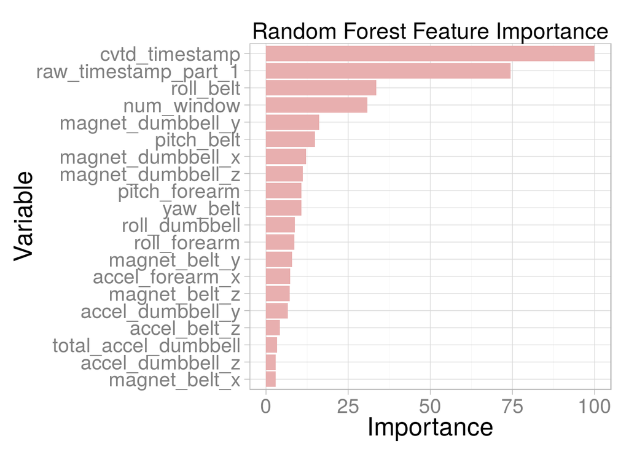

```r
dat = varImp(model_rf, type=2)
featureImportance <- data.frame(dat[1])
featureImportance$Var = rownames(featureImportance)
rownames(featureImportance) <- 1:nrow(featureImportance)

featureImportance$Var = as.character(featureImportance$Var)

## Var Plot
featureImportance = sqldf("select * from featureImportance order by Overall desc limit 20")
ggplot(featureImportance, aes(x=reorder(Var, order(Overall, decreasing = F)), y=Overall)) +
  geom_bar(stat="identity", fill="#E8AFAF") +
  coord_flip() +
  theme_light(base_size=20) +
  xlab("Variable") +
  ylab("Importance") +
  ggtitle("Random Forest Feature Importance") +
  theme(plot.title=element_text(size=18))
```

```r
featureImportance = sqldf("select Var from featureImportance order by Overall desc limit 20")

RfSelectedVariables = c()
for(x in 1:nrow(featureImportance)){
  RfSelectedVariables = c(RfSelectedVariables , c=featureImportance[[1]][x])
}
```

## Post Variable Selection Modeling

```r
system.time(model_rpart <- train(PMLTrain[,RfSelectedVariables], PMLTrain[,'classe'], method='rpart', trControl=myControl))
```

```
##    user  system elapsed
##   4.642   0.050   4.731
```

```r
system.time(model_rf <- train(PMLTrain[,RfSelectedVariables], PMLTrain[,'classe'], method='rf', trControl=myControl))
```

```
##    user  system elapsed
## 328.552   1.957 331.294
```

```r
system.time(model_nb <- train(PMLTrain[,RfSelectedVariables], PMLTrain[,'classe'], method='nb', trControl=myControl))
```

```
##    user  system elapsed
##  87.281   4.144  95.953
```

```r
# Model Selection
pred_rpart = predict(model_rpart, PMLTest[,RfSelectedVariables])
pred_rf = predict(model_rf, PMLTest[,RfSelectedVariables])
pred_NB = predict(model_nb, PMLTest[,RfSelectedVariables])
```

## Post Time Performance

Now that we are only using variables that directly influence our outcome we can see that our training time has essentially been cut in half.

## Post Variable Selection Modeling Results

```r
print('Tree Model')
```

```
## [1] "Tree Model"
```

```r
xtab <- table(pred_rpart, PMLTest$classe)
confusionMatrix(xtab)
```

```
## Confusion Matrix and Statistics
##
##
## pred_rpart    A    B    C    D    E
##          A 1436  123    0    0    0
##          B  796 1380 1008  241    0
##          C    0    0    0    0    0
##          D    0    0    0    0    0
##          E    0   15  360 1045 1442
##
## Overall Statistics
##
##                Accuracy : 0.5427
##                  95% CI : (0.5316, 0.5538)
##     No Information Rate : 0.2845
##     P-Value [Acc > NIR] : < 2.2e-16
##
##                   Kappa : 0.4226
##  Mcnemar's Test P-Value : NA
##
## Statistics by Class:
##
##                      Class: A Class: B Class: C Class: D Class: E
## Sensitivity            0.6434   0.9091   0.0000   0.0000   1.0000
## Specificity            0.9781   0.6768   1.0000   1.0000   0.7783
## Pos Pred Value         0.9211   0.4029      NaN      NaN   0.5038
## Neg Pred Value         0.8734   0.9688   0.8256   0.8361   1.0000
## Prevalence             0.2845   0.1935   0.1744   0.1639   0.1838
## Detection Rate         0.1830   0.1759   0.0000   0.0000   0.1838
## Detection Prevalence   0.1987   0.4365   0.0000   0.0000   0.3648
## Balanced Accuracy      0.8107   0.7930   0.5000   0.5000   0.8891
```

```r
print('RF Model')
```

```
## [1] "RF Model"
```

```r
xtab <- table(pred_rf, PMLTest$classe)
confusionMatrix(xtab)
```

```
## Confusion Matrix and Statistics
##
##
## pred_rf    A    B    C    D    E
##       A 2232    1    0    0    0
##       B    0 1517    0    0    0
##       C    0    0 1368    1    0
##       D    0    0    0 1285    4
##       E    0    0    0    0 1438
##
## Overall Statistics
##
##                Accuracy : 0.9992
##                  95% CI : (0.9983, 0.9997)
##     No Information Rate : 0.2845
##     P-Value [Acc > NIR] : < 2.2e-16
##
##                   Kappa : 0.999
##  Mcnemar's Test P-Value : NA
##
## Statistics by Class:
##
##                      Class: A Class: B Class: C Class: D Class: E
## Sensitivity            1.0000   0.9993   1.0000   0.9992   0.9972
## Specificity            0.9998   1.0000   0.9998   0.9994   1.0000
## Pos Pred Value         0.9996   1.0000   0.9993   0.9969   1.0000
## Neg Pred Value         1.0000   0.9998   1.0000   0.9998   0.9994
## Prevalence             0.2845   0.1935   0.1744   0.1639   0.1838
## Detection Rate         0.2845   0.1933   0.1744   0.1638   0.1833
## Detection Prevalence   0.2846   0.1933   0.1745   0.1643   0.1833
## Balanced Accuracy      0.9999   0.9997   0.9999   0.9993   0.9986
```

```r
print('NB Model')
```

```
## [1] "NB Model"
```

```r
xtab <- table(pred_NB, PMLTest$classe)
confusionMatrix(xtab)
```

```
## Confusion Matrix and Statistics
##
##
## pred_NB    A    B    C    D    E
##       A 2106  198   22    0   10
##       B   87 1058   92    8    4
##       C   38  255 1249  158   80
##       D    0    7    5 1086  136
##       E    1    0    0   34 1212
##
## Overall Statistics
##
##                Accuracy : 0.8553
##                  95% CI : (0.8474, 0.8631)
##     No Information Rate : 0.2845
##     P-Value [Acc > NIR] : < 2.2e-16
##
##                   Kappa : 0.8169
##  Mcnemar's Test P-Value : NA
##
## Statistics by Class:
##
##                      Class: A Class: B Class: C Class: D Class: E
## Sensitivity            0.9435   0.6970   0.9130   0.8445   0.8405
## Specificity            0.9590   0.9698   0.9180   0.9774   0.9945
## Pos Pred Value         0.9015   0.8471   0.7017   0.8801   0.9719
## Neg Pred Value         0.9771   0.9303   0.9804   0.9698   0.9651
## Prevalence             0.2845   0.1935   0.1744   0.1639   0.1838
## Detection Rate         0.2684   0.1348   0.1592   0.1384   0.1545
## Detection Prevalence   0.2977   0.1592   0.2269   0.1573   0.1589
## Balanced Accuracy      0.9513   0.8334   0.9155   0.9110   0.9175
```

## Results

A good rule of thumb is to always go with a simpler model. Based upon the variable selection RandomForest outperformed a single tree and the probablist model. However, I would still select the RandomForest because this model is not affecting an organizations bottom line or predicting a medical type treatment.

## Citation

Ugulino, W.; Cardador, D.; Vega, K.; Velloso, E.; Milidiu, R.; Fuks, H. Wearable Computing: Accelerometers’ Data Classification of Body Postures and Movements. Proceedings of 21st Brazilian Symposium on Artificial Intelligence. Advances in Artificial Intelligence - SBIA 2012. In: Lecture Notes in Computer Science. , pp. 52-61. Curitiba, PR: Springer Berlin / Heidelberg, 2012. ISBN 978-3-642-34458-9. DOI: 10.1007/978-3-642-34459-6_6. Cited by 2 (Google Scholar)